# COMPSCIX 415.2 Homework 5/Midterm

Yasmin Makoui

7/10/2018

```r
library(tidyverse)
library(mdsr)
```

My Github repository for my midterm can be found at this URL: https://github.com/yasi1362/CompScix-415-2-assignments/tree/master/Midterm

## The tidyverse packages

### Q1

#### Can you name which package is associated with each task below?

###### Plotting - ggplot2

###### Data munging/wrangling - dplyr

###### Reshaping(spreading & gathering) data - tidyr

###### Importing/exporting data - readr

### Q2

#### Now can you name two functions that you’ve used from each package that you listed above for these tasks?

###### Plotting:

- geom function -> geom_point()
- theme function -> theme_bw()

###### Data munging/wrangling:

- summarise()
- filter()

###### Reshaping data:

- gather()
- spread()

###### Importing/exporting data:

- read_csv()
- read_delim()

## R Basics

### Q1

#### Fix this code with the fewest number of changes possible so it works:

##### My_data.name___is.too00ooLong! <- c( 1 , 2 , 3 )

##### ! can not be used to name a variable

```r
My_data.name___is.too00ooLong <- c( 1 , 2 , 3 )
My_data.name___is.too00ooLong
```

```
## [1] 1 2 3
```

### Q2

#### Fix this code so it works:

##### my_string <- C(‘has’, ‘an’, ‘error’, ‘in’, ’it)

##### c should not be capitalized, and the closing ’ was missing for “it”

```r
my_string <- c('has', 'an', 'error', 'in', 'it')
my_string
```

```
## [1] "has"   "an"    "error" "in"    "it"
```

### Q3

#### Look at the code below and comment on what happened to the values in the vector.

##### my_vector <- c(1, 2, ‘3’, ‘4’, 5)

##### [1] “1” “2” “3” “4” “5”

##### Since number 3 and 4 were inside quotes the values changed from numbers to characters. To keep the values as numbers we should not include the quotes around numbers.

```r
my_vector <- c(1, 2, 3, 4, 5)
my_vector
```

```
## [1] 1 2 3 4 5
```

## Data import/export

### Q1

#### 1. Download the rail_trail.txt file from Canvas (in the Midterm Exam section) and successfully import it into R. Prove that it was imported successfully by including your import code and taking a glimpse of the result.

```r
#import text file
file_path_rail_trail_txt <- '/Users/yasminmakoui/downloads/rail_trail.txt'
rail_trail_data <- read_delim(delim = '|', file = file_path_rail_trail_txt)
#glimpse of imported text file
glimpse(rail_trail_data)
```

```
## Observations: 90
## Variables: 10
## $ hightemp   <int> 83, 73, 74, 95, 44, 69, 66, 66, 80, 79, 78, 65, 41,...
## $ lowtemp    <int> 50, 49, 52, 61, 52, 54, 39, 38, 55, 45, 55, 48, 49,...
## $ avgtemp    <dbl> 66.5, 61.0, 63.0, 78.0, 48.0, 61.5, 52.5, 52.0, 67....
## $ spring     <int> 0, 0, 1, 0, 1, 1, 1, 1, 0, 0, 0, 1, 1, 0, 0, 1, 0, ...
## $ summer     <int> 1, 1, 0, 1, 0, 0, 0, 0, 1, 1, 1, 0, 0, 0, 0, 0, 1, ...
## $ fall       <int> 0, 0, 0, 0, 0, 0, 0, 0, 0, 0, 0, 0, 0, 1, 1, 0, 0, ...
## $ cloudcover <dbl> 7.6, 6.3, 7.5, 2.6, 10.0, 6.6, 2.4, 0.0, 3.8, 4.1, ...
## $ precip     <dbl> 0.00, 0.29, 0.32, 0.00, 0.14, 0.02, 0.00, 0.00, 0.0...
## $ volume     <int> 501, 419, 397, 385, 200, 375, 417, 629, 533, 547, 4...
## $ weekday    <int> 1, 1, 1, 0, 1, 1, 1, 0, 0, 1, 1, 1, 1, 1, 1, 1, 0, ...
```

### Q2

#### Export the file into a comma-separated file and name it “rail_trail.csv”. Make sure you define the path correctly so that you know where it gets saved. Then reload the file. Include your export and import code and take another glimpse.

```r
#export csv file
write_csv(rail_trail_data, path = '/Users/yasminmakoui/downloads/rail_trail.csv')

#import csv file
file_path_rail_trail_csv <- '/Users/yasminmakoui/downloads/rail_trail.csv'
rail_trail_data_csv <- read_csv(file = file_path_rail_trail_csv)
#glimpse csv file
glimpse(rail_trail_data_csv)
```

```
## Observations: 90
## Variables: 10
## $ hightemp   <int> 83, 73, 74, 95, 44, 69, 66, 66, 80, 79, 78, 65, 41,...
## $ lowtemp    <int> 50, 49, 52, 61, 52, 54, 39, 38, 55, 45, 55, 48, 49,...
## $ avgtemp    <dbl> 66.5, 61.0, 63.0, 78.0, 48.0, 61.5, 52.5, 52.0, 67....
## $ spring     <int> 0, 0, 1, 0, 1, 1, 1, 1, 0, 0, 0, 1, 1, 0, 0, 1, 0, ...
## $ summer     <int> 1, 1, 0, 1, 0, 0, 0, 0, 1, 1, 1, 0, 0, 0, 0, 0, 1, ...
## $ fall       <int> 0, 0, 0, 0, 0, 0, 0, 0, 0, 0, 0, 0, 0, 1, 1, 0, 0, ...
## $ cloudcover <dbl> 7.6, 6.3, 7.5, 2.6, 10.0, 6.6, 2.4, 0.0, 3.8, 4.1, ...
## $ precip     <dbl> 0.00, 0.29, 0.32, 0.00, 0.14, 0.02, 0.00, 0.00, 0.0...
## $ volume     <int> 501, 419, 397, 385, 200, 375, 417, 629, 533, 547, 4...
## $ weekday    <int> 1, 1, 1, 0, 1, 1, 1, 0, 0, 1, 1, 1, 1, 1, 1, 1, 0, ...
```

## Visualization

### Q1

#### Critique the graphic provided in midterm: give only three examples of what is wrong with this graphic. Be concise.

1. The size of the circles do not represent the percentages. For example for women category the circle for the 20% is much smaller than the 72%, and it could be misleading.
2. Each category does not add up to 100%.
3. This visual does not show the total population in the study or the numbers of each category that participated in the study. The data could be skewed depending on who participate in this study.

### Q2

#### Reproduce this graphic using the diamonds data set.

##### See below:

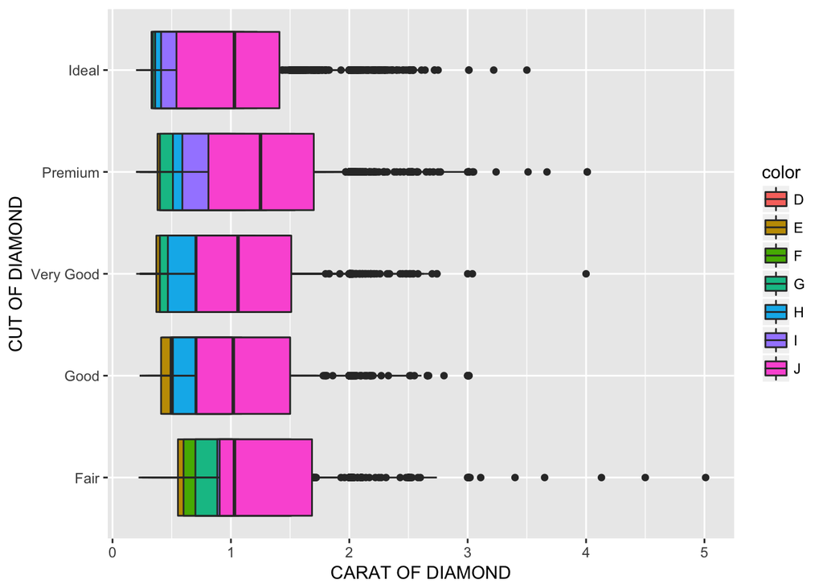

```r
ggplot(data = diamonds) +
  geom_boxplot(mapping = aes(x = cut, y = carat, fill = color), position = "identity") + xlab("CUT OF DIAMOND") + ylab("CARAT OF DIAMOND") +
  coord_flip()
```

### Q3

#### The previous graphic is not very useful. We can make it much more useful by changing one thing about it. Make the change and plot it again.

##### The previous graph was not really clear on the colors since some where overlapping. Position “dodge” will seperate each color category.

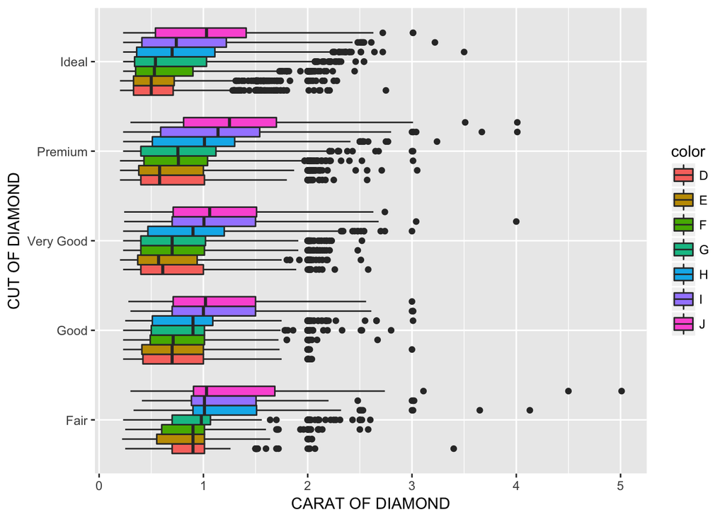

```r
?geom_boxplot
ggplot(data = diamonds) +
  geom_boxplot(mapping = aes(x = cut, y = carat, fill = color ), position = "dodge") + xlab("CUT OF DIAMOND") + ylab("CARAT OF DIAMOND") +
  coord_flip()
```

## Data munging and wrangling

### Q1

#### Is this data “tidy”? If yes, leave it alone and go to the next problem. If no, make it tidy. Note: this data set is called table2 and is available in the tidyverse package. It should be ready for you to use after you’ve loaded the tidyverse package.

##### This data is not tidy since the cases and population are in the same column and the count for each are not seperated. We can tidy the table by usind a spread function to seperate cases and population counts.

```r
table2
```

```
## # A tibble: 12 x 4
##    country      year type            count
##    <chr>       <int> <chr>           <int>
##  1 Afghanistan  1999 cases             745
##  2 Afghanistan  1999 population   19987071
##  3 Afghanistan  2000 cases            2666
##  4 Afghanistan  2000 population   20595360
##  5 Brazil       1999 cases           37737
##  6 Brazil       1999 population  172006362
##  7 Brazil       2000 cases           80488
##  8 Brazil       2000 population  174504898
##  9 China        1999 cases          212258
## 10 China        1999 population 1272915272
## 11 China        2000 cases          213766
## 12 China        2000 population 1280428583
```

```r
spread(table2, key = type, value = count)
```

```
## # A tibble: 6 x 4
##   country      year  cases population
##   <chr>       <int>  <int>      <int>
## 1 Afghanistan  1999    745   19987071
## 2 Afghanistan  2000   2666   20595360
## 3 Brazil       1999  37737  172006362
## 4 Brazil       2000  80488  174504898
## 5 China        1999 212258 1272915272
## 6 China        2000 213766 1280428583
```

### Q2

#### Create a new column in the diamonds data set called price_per_carat that shows the price of each diamond per carat (hint: divide). Only show me the code, not the output

> diamonds %>% mutate(price_per_carat = price/carat)

### Q3

#### For each cut of diamond in the diamonds data set, how many diamonds, and what proportion, have a price > 10000 and a carat < 1.5? There are several ways to get to an answer, but your solution must use the data wrangling verbs from the tidyverse in order to get credit.

- Do the results make sense? Why? Yes, based on the total population and the graph below, most of the diamonds with price abouve $10,000 are bigger that 1.5 carat.
- Do we need to be wary of any of these numbers? Why? I think this data should be reliable.

##### There are 834 diamonds over $10,000 that are smaller than 1.5 carats in the diamond data set

##### There are 53,940 observations in the diamonds data set, and the poroportaion of small diamonds to the total population is about 1.5%

```r
expensive_diamonds <- filter( diamonds, price > 10000,  carat < 1.5)
count(expensive_diamonds)
```

```
## # A tibble: 1 x 1
##       n
##   <int>
## 1   834
```

```r
count(diamonds)
```

```
## # A tibble: 1 x 1
##       n
##   <int>
## 1 53940
```

```r
Diamonds_ratio <- (count(expensive_diamonds) / count(diamonds))

Diamonds_ratio
```

```
##            n
## 1 0.01546162
```

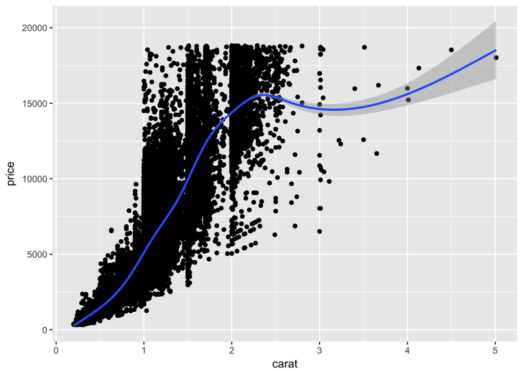

```r
ggplot(data = diamonds, mapping = aes(x = carat, y = price) ) +
         geom_point() + geom_smooth()
```

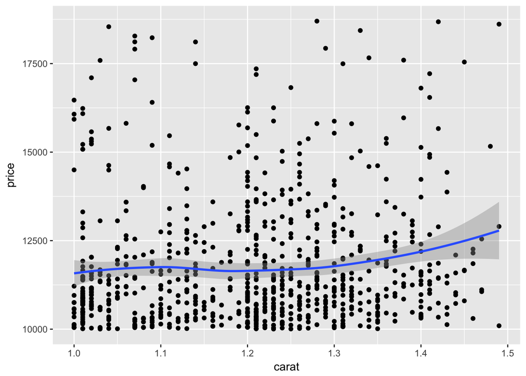

```r
ggplot(data = expensive_diamonds, mapping = aes(x = carat, y = price) ) +
         geom_point() + geom_smooth()
```

## EDA

### Q1

#### During what time period is this data from? 2000 - 2015

```r
years <- txhousing %>% select(year) %>% group_by(year)

summarise(years)
```

```
## # A tibble: 16 x 1
##     year
##    <int>
##  1  2000
##  2  2001
##  3  2002
##  4  2003
##  5  2004
##  6  2005
##  7  2006
##  8  2007
##  9  2008
## 10  2009
## 11  2010
## 12  2011
## 13  2012
## 14  2013
## 15  2014
## 16  2015
```

### Q2

#### How many cities are represented? 46 cities

```r
cities <- group_by(count(txhousing, city))

cities
```

```
## # A tibble: 46 x 2
##    city                      n
##    <chr>                 <int>
##  1 Abilene                 187
##  2 Amarillo                187
##  3 Arlington               187
##  4 Austin                  187
##  5 Bay Area                187
##  6 Beaumont                187
##  7 Brazoria County         187
##  8 Brownsville             187
##  9 Bryan-College Station   187
## 10 Collin County           187
## # ... with 36 more rows
```

### Q3

#### Which city, month and year had the highest number of sales? Houston in July 2015 had the highest sales of 8945.

```r
subset <- txhousing %>% select(city, month, year, sales)

arrange(subset, desc(sales))
```

```
## # A tibble: 8,602 x 4
##    city    month  year sales
##    <chr>   <int> <int> <dbl>
##  1 Houston     7  2015  8945
##  2 Houston     6  2006  8628
##  3 Houston     7  2013  8468
##  4 Houston     6  2015  8449
##  5 Houston     5  2013  8439
##  6 Houston     6  2014  8391
##  7 Houston     7  2014  8391
##  8 Houston     8  2014  8167
##  9 Houston     8  2013  8155
## 10 Houston     5  2006  8040
## # ... with 8,592 more rows
```

### Q4

#### What kind of relationship do you think exists between the number of listings and the number of sales? Check your assumption and show your work.

##### There is a positive relationship between number of sales and number of listings. The higher the number of listings in average the higher number of sales.

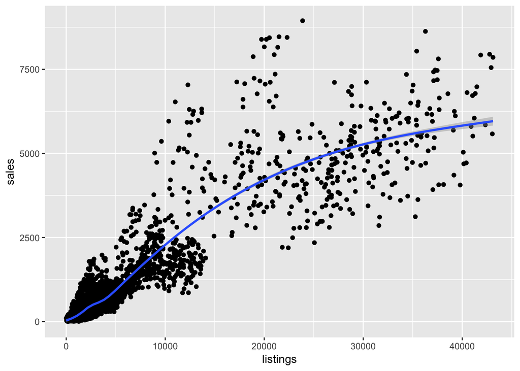

```r
ggplot(txhousing, mapping = aes(x = listings, y = sales)) +
  geom_jitter() + geom_smooth()
```

### Q5

#### What proportion of sales is missing for each city?

```r
missing_sales <- txhousing %>% filter(is.na(sales))
count(missing_sales)
```

```
## # A tibble: 1 x 1
##       n
##   <int>
## 1   568
```

```r
txhousing %>% mutate(missingsales = (is.na(sales))) %>%
  group_by(city) %>%
  summarize(num_missingsales = sum(missingsales),
            num_sales = sum(sales, na.rm = TRUE),
            prop_missing = num_missingsales/num_sales)
```

```
## # A tibble: 46 x 4
##    city                  num_missingsales num_sales prop_missing
##    <chr>                            <int>     <dbl>        <dbl>
##  1 Abilene                              0     28141     0
##  2 Amarillo                             0     44628     0
##  3 Arlington                            0     79285     0
##  4 Austin                               0    373381     0
##  5 Bay Area                             0     93989     0
##  6 Beaumont                             0     33110     0
##  7 Brazoria County                     14     16302     0.000859
##  8 Brownsville                          2     12121     0.000165
##  9 Bryan-College Station                0     34921     0
## 10 Collin County                        0    202892     0
## # ... with 36 more rows
```

### Q6

#### Looking at only the cities and months with greater than 500 sales:

```r
txhousing_sales_over <- filter(txhousing, sales > 500)

txhousing_sales_over %>% mutate(sales_over = (sales > 500)) %>%
  group_by(city, month, year, median) %>%
  summarize(total_sales = sum(sales, na.rm = TRUE),
            new_median = median(median, na.rm = TRUE),
            difference = new_median - median)
```

```
## # A tibble: 1,883 x 7
## # Groups:   city, month, year [?]
##    city      month  year median total_sales new_median difference
##    <chr>     <int> <int>  <dbl>       <dbl>      <dbl>      <dbl>
##  1 Arlington     3  2006 129500         578     129500          0
##  2 Arlington     3  2007 131700         573     131700          0
##  3 Arlington     4  2005 124600         548     124600          0
##  4 Arlington     4  2006 128600         583     128600          0
##  5 Arlington     4  2007 129200         541     129200          0
##  6 Arlington     5  2001 114400         536     114400          0
##  7 Arlington     5  2002 116100         503     116100          0
##  8 Arlington     5  2003 118000         502     118000          0
##  9 Arlington     5  2004 118300         527     118300          0
## 10 Arlington     5  2005 124200         579     124200          0
## # ... with 1,873 more rows
```

- Any cities that stand out that you’d want to investigate further? i would like to investigate more about city of Houston, since it has the highest sales across the board.

```r
txhousing_sales_over <- filter(txhousing, sales > 500)

txhousing_sales_over %>% mutate(sales_over = (sales > 500)) %>%
  group_by(city) %>%
  summarize(total_sales = sum(sales, na.rm = TRUE),
            new_median = median(median, na.rm = TRUE),
            ) %>% arrange(desc(total_sales))
```

```
## # A tibble: 14 x 3
##    city              total_sales new_median
##    <chr>                   <dbl>      <dbl>
##  1 Houston               1043999     148400
##  2 Dallas                 816122     154500
##  3 Austin                 373381     179400
##  4 San Antonio            322097     143300
##  5 Collin County          201943     196000
##  6 Fort Bend              148153     177500
##  7 Fort Worth             138022     114600
##  8 NE Tarrant County      115579     160800
##  9 Denton County           94843     163200
## 10 Montgomery County       72994     178750
## 11 Bay Area                52194     156250
## 12 El Paso                 41114     131200
## 13 Arlington               23000     129300
## 14 Corpus Christi           2626     129300
```

- Why might we want to filter out all cities and months with sales less than 500? When we want to know the strongest value and derivers of sales we would want to filter out the not significant observations.